# R package: FourSeasons

Simeon Lisovski

2017-03-14

This ‘R’ Package contains the analytically tool set to derive major seasonal components as described in Lisovski et al. 2017[^1]. In particular, this package has two functions:

- defineSeasons
- AmpPred

In the following paragraphs I aim to provide a short description in both functions based on a dataset of minimum and maximum temperature recordings from a weather station within the Yellowstone National Park.

## **The dataset**

Summary of daily minimum and maximum temperature recordings from the land based NOAA[^2] weather station called *LAKE YELLOWSTONE* was downloaded and included into this package as an example dataset.

```r
library(FourSeasons)
  data("tempYNP")

tempYNP[1:5, c("Date", "Tmax", "Tmin")]
```

```
##         Date Tmax Tmin
## 1 1995-01-01    8  -32
## 2 1995-01-02    6  -30
## 3 1995-01-03    8  -31
## 4 1995-01-04    8  -32
## 5 1995-01-05    9  -29
```

The dataset includes temperature recordings from the following period:

```r
range(tempYNP$Date)
```

```
## [1] "1995-01-01 GMT" "2015-12-31 GMT"
```

## **defineSeasons**

The first function - *defineSeasons* - helps to define the periodicity within seasonal dataset (e.g. annual, bi-annual) that is later used to split periods, the e.g. annual cycle, and investigate them in isolation and in comparison to the other periods. In addition, the function uses tools to decompose the dataset into a seasonal, a trend and a remaining component that can be plotted and may be used for further investigations.

The functions requires definition of the following arguments:

- **tm**
  - the timestamp of the observations. Needs to be a POSIXc or POSIXl class object (see: ?as.POSIXct).
- **y**
  - the observation (e.g. Tmin or Tmax of the Yellowstone dataset)
- **frequency**
  - the frequency of the observations; so far either ‘daily’, ‘weekly’ or ‘monthly’.
- **plot**
  - logical, if TRUE a summary plot will be produced.

```r
sTab <- defineSeasons(tempYNP$Date, tempYNP$Tmin, frequency = "daily")
```

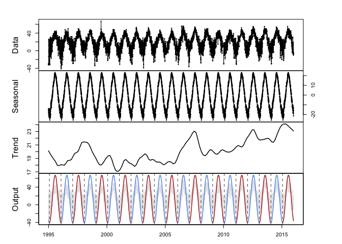

The upper panel shows the raw data with grey points indicating interpolated values (nessesary for further analysis with *AmpPred*). The second panel shows the seasonal component of the dataset, wheareas the third indicades the trend component over time. The lower panel shows again the raw data (grey) and a fitted cosine function that is then used to split the time-series into consecutive seasonal periods.

The output provides a data frame with the following variables:

```r
head(sTab)
```

```
##         date   y period  seasonal    trend remainder   cos.fit
## 1 1995-01-01 -32      1 -15.37300 20.13184 -36.75884 -17.46103
## 2 1995-01-02 -30      1 -13.95741 20.12355 -36.16613 -17.61289
## 3 1995-01-03 -31      1 -16.08823 20.11526 -35.02703 -17.75954
## 4 1995-01-04 -32      1 -18.66223 20.10697 -33.44474 -17.90093
## 5 1995-01-05 -29      1 -21.41805 20.09867 -27.68063 -18.03702
## 6 1995-01-06 -13      1 -16.32287 20.09038 -16.76751 -18.16776
```

## **AmpPred**

The *AmpPred* function uses the data frame complied by the *defineSeason* function and generates future predictions based on a subset of the dataset. Those predictions are then used to estimate the goodness of the predictions by calculating the R^2 between the predictions and the raw data. Furthermore, the function calcualtes the amplitude of the within seasonal dynamic.

The function requires the definition of the following arguments:

- **data**
  - data.frame as produced by defineSeasons.
- **info.periods**
  - the number of periods used as prior inforamtion to generate predictions.
- **forecast.period**
  - the number of periods to be forecasted within each step.
- **cuttoff**
  - exlude incomplete periods (in the beginning and the end); the cuttoff defines a percetnage of the complete periods.
- **amp.probs**
  - the qunatiles used to define the seasonal amplitude.
- **plot**
  - logical, of TRUE a plot will be drawn.

```r
seas <- AmpPred(sTab, info.periods = 4, forecast.periods = 1)
```

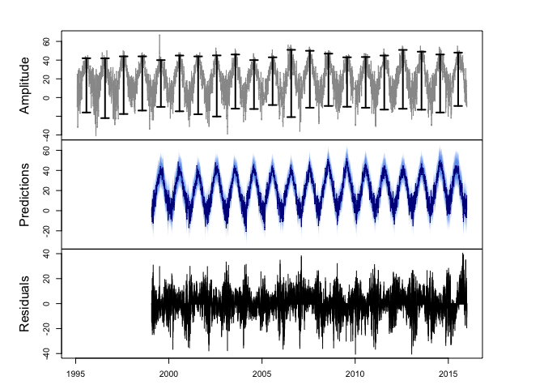

The output provies a list with a summary data frame as well as the entire forcasting data (2nd data frame).

```r
seas$summary[1:8,] ## First 8 rows of the summary output
```

```
##   date.start   date.end period amplitude predictability
## 1 1995-01-30 1996-01-29      2     58.00             NA
## 2 1996-01-30 1997-01-28      3     63.90             NA
## 3 1997-01-29 1998-01-28      4     61.60             NA
## 4 1998-01-29 1999-01-28      5     57.90             NA
## 5 1999-01-29 2000-01-28      6     50.00      0.6294299
## 6 2000-01-29 2001-01-27      7     59.60      0.6356223
## 7 2001-01-28 2002-01-27      8     61.85      0.6519944
## 8 2002-01-28 2003-01-27      9     65.30      0.6532825
```